# BI Applications in Payment Industry

Anna Huynh

2022-07-17

## Business Goals:

1. How does a financial institution increase market share in consumer credit cards?
2. How should a credit card issuer/ merchants use emerging technology to acquire the best customers?
3. How does a financial institution grow their credit card portfolio while mitigating credit risk?

How does a financial institution optimize their product offering? How should a credit card issuer use digital and emerging technology to acquire and retain the best customers?

**Data Sources:** Store Market Sales Data Invoice id: Computer generated sales slip invoice identification number

Branch: Branch of supercenter (3 branches are available identified by A, B and C).

City: Location of supercenters

Customer type: Type of customers, recorded by Members for customers using member card and Normal for without member card.

Gender: Gender type of customer

Product line: General item categorization groups - Electronic accessories, Fashion accessories, Food and beverages, Health and beauty, Home and lifestyle, Sports and travel

Unit price: Price of each product in $

Quantity: Number of products purchased by customer

Tax: 5% tax fee for customer buying

Total: Total price including tax

Date: Date of purchase (Record available from January 2019 to March 2019)

Time: Purchase time (10am to 9pm)

Payment: Payment used by customer for purchase (3 methods are available – Cash, Credit card and Ewallet)

COGS: Cost of goods sold

Gross margin percentage: Gross margin percentage

Gross income: Gross income

Rating: Customer stratification rating on their overall shopping experience (On a scale of 1 to 10)

URL: https://www.kaggle.com/datasets/neoanderson144/supermarketsales?select=supermarketsales.json

```r
library(dplyr)
library(jsonlite)
library(viridis)
library(hrbrthemes)
library(lubridate)
```

```r
library(ggplot2)
```

```r
# read, flatten json file, and convert to data frame

salesdt <- flatten(fromJSON(txt = "C:/Users/Anhuynh/Desktop/ITU/Classes/Principles of Business Analytics/Assignments/Dataset/supermarketsales.json"))

tab_list <- lapply(1:nrow(salesdt),
                  function(i) data.frame(salesdt[i, -17], salesdt[i, 17],
                              stringsAsFactors = FALSE))
library(dplyr)
flat_table <- bind_rows(tab_list)
```

```r
# calculate Revenue
salesdf <- cbind(flat_table, Revenue = flat_table$cogs/(1-flat_table$gross.margin.percentage/100))

# rename a column
colnames(salesdf)[17] <- "Rating"

# convert from "char" to "date"
salesdf$Date <- mdy(salesdf$Date)
```

```r
##Find missing values
colSums(is.na(salesdf))
```

```
##              Invoice.ID                  Branch                    City
##                       0                       0                       0
##           Customer.type                  Gender            Product.line
##                       0                       0                       0
##              Unit.price                Quantity                  Tax.5.
##                       0                       0                       0
##                   Total                    Date                    Time
##                       0                       0                       0
##                 Payment                    cogs gross.margin.percentage
##                       0                       0                       0
##            gross.income                  Rating                 Revenue
##                       0                       0                       0
```

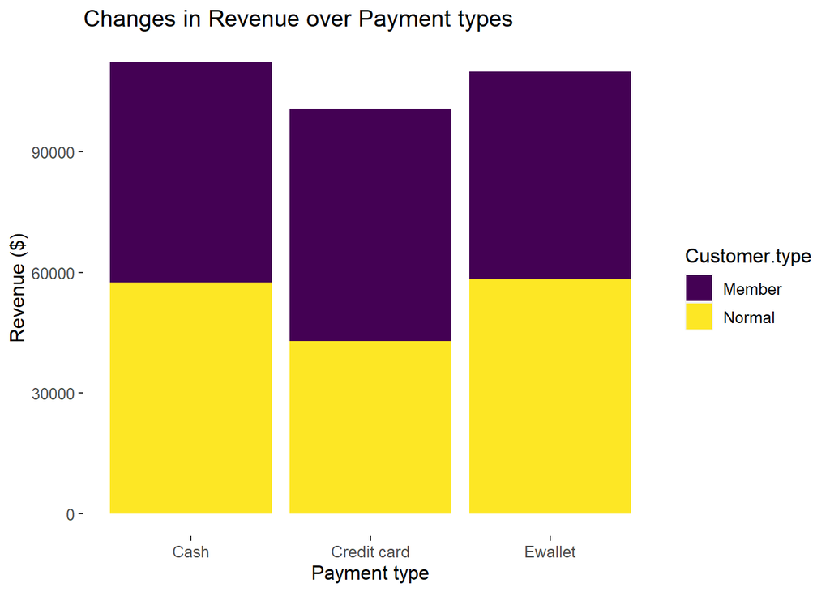

```r
# Changes in revenue over Payment type and Customer type
ggplot(salesdf, aes(fill=Customer.type, y=Revenue, x=Payment)) +
    geom_bar(position="stack", stat="identity") +
    scale_fill_viridis(discrete = T) +
    ggtitle("Changes in Revenue over Payment types") +
   theme(text = element_text(size = 12),
          panel.grid.major = element_blank(),
    panel.grid.minor = element_blank(),
    panel.border = element_blank(),
    panel.background = element_blank()) +
    xlab("") +
    labs(x="Payment type",y="Revenue ($)")
```

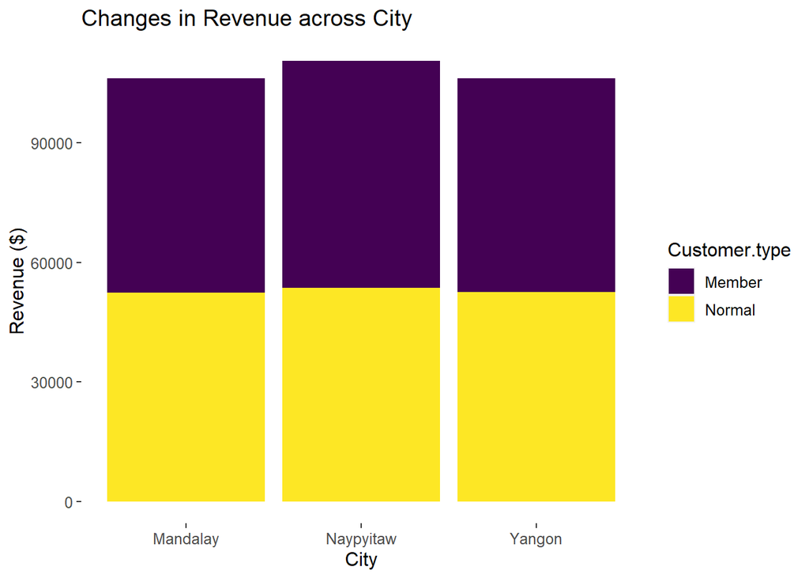

```r
ggplot(salesdf, aes(fill=Customer.type, y=Revenue, x=City)) +
    geom_bar(position="stack", stat="identity") +
    scale_fill_viridis(discrete = T) +
    ggtitle("Changes in Revenue across City") +
   theme(text = element_text(size = 12),
          panel.grid.major = element_blank(),
    panel.grid.minor = element_blank(),
    panel.border = element_blank(),
    panel.background = element_blank()) +
    xlab("") +
    labs(x="City",y="Revenue ($)")
```

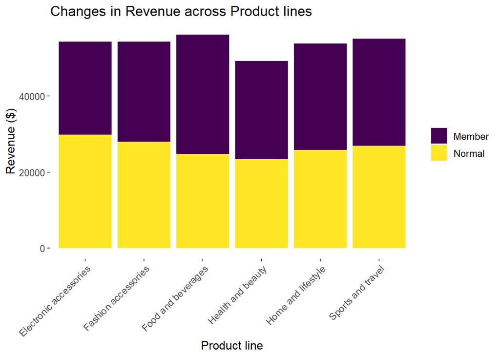

```r
ggplot(salesdf, aes(fill=Customer.type, y=Revenue, x=Product.line)) +
    geom_bar(position="stack", stat="identity") +
    scale_fill_viridis(discrete = T) +
    ggtitle("Changes in Revenue across Product lines") +
   theme(text = element_text(size = 12)) +
    xlab("") +
    labs(x="Product line",y="Revenue ($)") +
   theme(legend.title = element_blank(),     axis.text.x=element_text(angle=45,hjust=1,vjust=1),
          panel.grid.major = element_blank(),
    panel.grid.minor = element_blank(),
    panel.border = element_blank(),
    panel.background = element_blank())
```

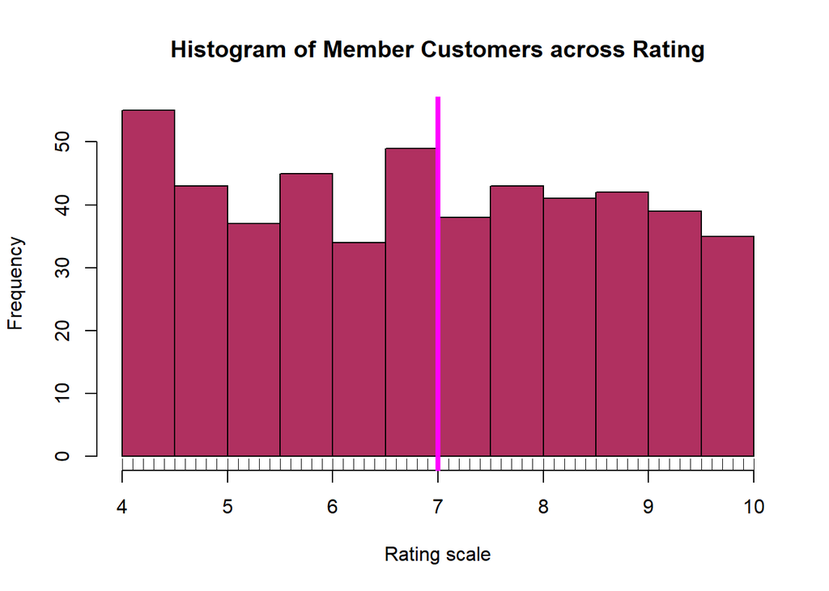

```r
# Distribution of the variables counts, or how many patients fall into each bucket of measurements.

hist(salesdf$Rating[which(salesdf$Customer.type == "Member")], col = "maroon",
     xlab='Rating scale', main=paste0(
     "Histogram of Member Customers across Rating"))
rug(salesdf$Rating)
abline(v = median(salesdf$Rating), col = "magenta", lwd = 4)
```

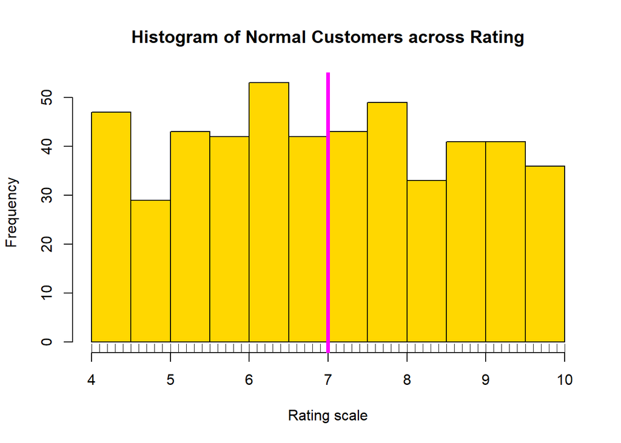

```r
hist(salesdf$Rating[which(salesdf$Customer.type == "Normal")], col = "gold",
     xlab='Rating scale', main=paste0(
     "Histogram of Normal Customers across Rating"))
rug(salesdf$Rating)
abline(v = median(salesdf$Rating), col = "magenta", lwd = 4)
```

```r
library(reshape2)
# create new dataset, convert column values into rows
salesdf$Date <- as.factor(salesdf$Date)
sales <- melt(salesdf[c("cogs", "Revenue", "Date")])
```

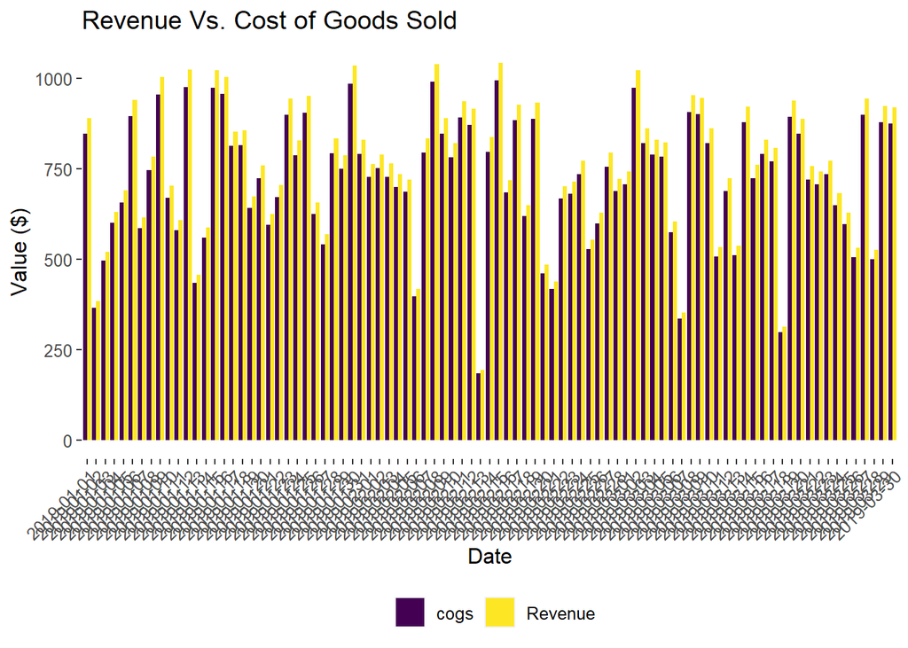

```r
ggplot(sales, aes(fill=variable, y=value, x=Date)) +
    geom_bar(position="dodge", stat="identity") +
    scale_fill_viridis(discrete = T) +
    ggtitle("Revenue Vs. Cost of Goods Sold") +
   theme(text = element_text(size = 12)) +
    xlab("") +
    labs(x="Date",y="Value ($)") +
   theme(legend.title = element_blank(),     axis.text.x=element_text(angle=45,hjust=1,vjust=1),
          panel.grid.major = element_blank(),
    panel.grid.minor = element_blank(),
    panel.border = element_blank(),
    panel.background = element_blank()) +
   theme(legend.position="bottom")
```

```r
# Identify important variables and build models

library(tidymodels)
## Step 1: Split the data into training and test sets
set.seed(2022)
salesdf_split <- initial_split(salesdf,  prop = 3/4)
sales_train <- training(salesdf_split) # training set
sales_test <- testing(salesdf_split) # test set
```

**Feature Engineering.**

```r
sales_train_imp <- sales_train %>%
  transmute(
        Branch,
        City,
        Customer.type = ifelse(Customer.type == "Member", 1, 0),
    Gender = ifelse(Gender == "Female", 1, 0),
    Product.line,
    Unit.price,
    Quantity,
    Tax.5.,
    Total,
    Payment = ifelse(Payment == "Credit card", 1, 0) ,
    cogs,
    gross.income,
    Rating
    )

sales_test_imp <- sales_test %>%
  transmute(
        Branch,
        City,
        Customer.type = ifelse(Customer.type == "Member", 1, 0),
    Gender = ifelse(Gender == "Female", 1, 0),
    Product.line,
    Unit.price,
    Quantity,
    Tax.5.,
    Total,
    Payment = ifelse(Payment == "Credit card", 1, 0) ,
    cogs,
    gross.income,
    Rating
    )
```

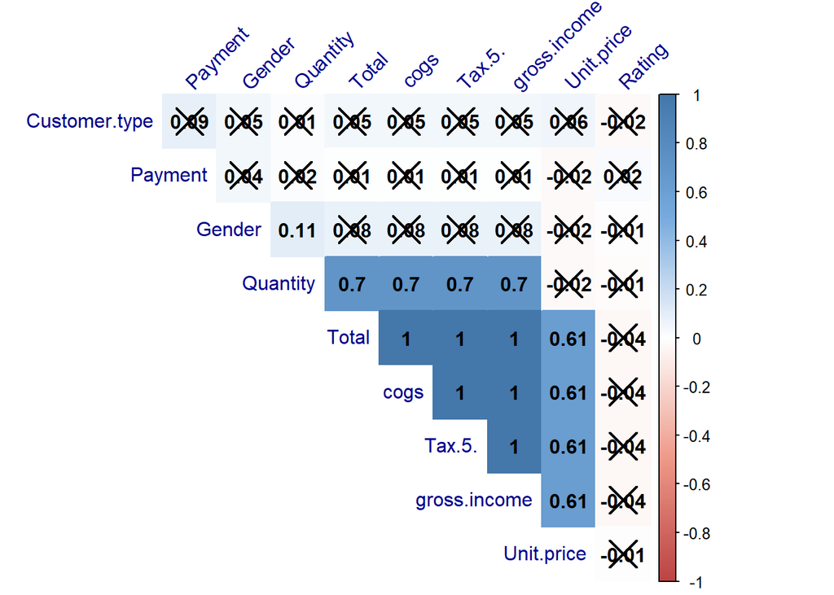

```r
library(corrplot)
library(Hmisc)
## Mark the insignificant coefficients according to the specified p-value significance level
cor_9 <- rcorr(as.matrix(sales_train_imp[-c(1,2,5)]))
sales_train_imp_cor <- cor_9$r
p_mat <- cor_9$P

col <- colorRampPalette(c("#BB4444", "#EE9988", "#FFFFFF", "#77AADD", "#4477AA"))

corrplot(sales_train_imp_cor, method = "color", col = col(200),
         type = "upper", order = "hclust",
         addCoef.col = "black", # Add coefficient of correlation
         tl.col = "darkblue", tl.srt = 45, #Text label color and rotation
         # Combine with significance level
         p.mat = p_mat, sig.level = 0.01,
         # hide correlation coefficient on the principal diagonal
         diag = FALSE
         )
```

```r
library(e1071)
library(gmodels)
library(caret)
library(pROC)
library(ROCR)

## Naive Bayes
# accuracy = TP + TN /(TP + TN + FP + FN)
# error rate = 1 - accuracy


sales_classifier <- naiveBayes(sales_train_imp, sales_train_imp$Customer.type)

sales_class_pred <- predict(sales_classifier, sales_test_imp )

CrossTable(sales_class_pred, sales_test_imp$Customer.type,
 prop.chisq = FALSE, prop.c = FALSE, prop.r = FALSE,
 dnn = c('predicted', 'actual'))
```

```
##
##
##    Cell Contents
## |-------------------------|
## |                       N |
## |         N / Table Total |
## |-------------------------|
##
##
## Total Observations in Table:  250
##
##
##              | actual
##    predicted |         0 |         1 | Row Total |
## -------------|-----------|-----------|-----------|
##            0 |       140 |         0 |       140 |
##              |     0.560 |     0.000 |           |
## -------------|-----------|-----------|-----------|
##            1 |         0 |       110 |       110 |
##              |     0.000 |     0.440 |           |
## -------------|-----------|-----------|-----------|
## Column Total |       140 |       110 |       250 |
## -------------|-----------|-----------|-----------|
##
##
```

**Random Forest Model**

```r
library(randomForest)
```

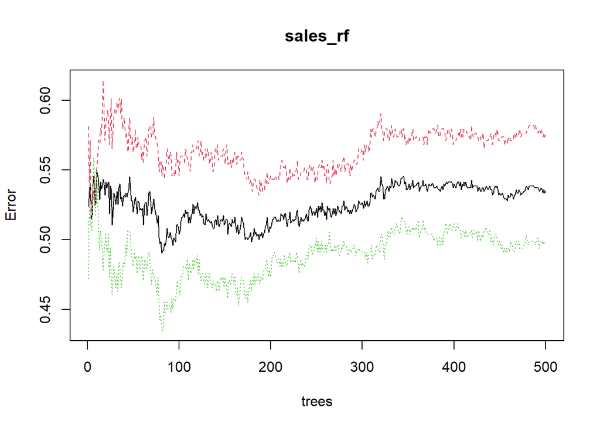

```r
library(caret)
library(pROC)
library(ROCR)

sales_train_imp$Customer.type <- factor(sales_train_imp$Customer.type)

sales_test_imp$Customer.type <- factor(sales_test_imp$Customer.type)

## Check number of trees (ntree = 100)
sales_rf <- randomForest(Customer.type ~ .,
                data = sales_train_imp)

plot(sales_rf)
```

```r
## Build model
control_rf <- trainControl(method = "cv", 5)

sales_rf <- train(Customer.type ~ .,
                data = sales_train_imp, method="rf",
                  trControl=control_rf, ntree=100
                  )
sales_rf
```

```
## Random Forest
##
## 750 samples
##  12 predictor
##   2 classes: '0', '1'
##
## No pre-processing
## Resampling: Cross-Validated (5 fold)
## Summary of sample sizes: 600, 600, 600, 599, 601
## Resampling results across tuning parameters:
##
##   mtry  Accuracy   Kappa
##    2    0.4694578  -0.061161991
##   10    0.4735025  -0.058528987
##   18    0.5055472   0.007279281
##
## Accuracy was used to select the optimal model using the largest value.
## The final value used for the model was mtry = 18.
```

```r
predict_rf <- predict(sales_rf, sales_test_imp)

confusionMatrix(sales_test_imp$Customer.type, predict_rf)
```

```
## Confusion Matrix and Statistics
##
##           Reference
## Prediction  0  1
##          0 62 78
##          1 53 57
##
##                Accuracy : 0.476
##                  95% CI : (0.4127, 0.5399)
##     No Information Rate : 0.54
##     P-Value [Acc > NIR] : 0.9817
##
##                   Kappa : -0.038
##
##  Mcnemar's Test P-Value : 0.0360
##
##             Sensitivity : 0.5391
##             Specificity : 0.4222
##          Pos Pred Value : 0.4429
##          Neg Pred Value : 0.5182
##              Prevalence : 0.4600
##          Detection Rate : 0.2480
##    Detection Prevalence : 0.5600
##       Balanced Accuracy : 0.4807
##
##        'Positive' Class : 0
##
```

```r
# Out-of-sample-error in test set
OOSE <- 1 - as.numeric(confusionMatrix(sales_test_imp$Customer.type, predict_rf)$overall[1])
OOSE
```

```
## [1] 0.524
```

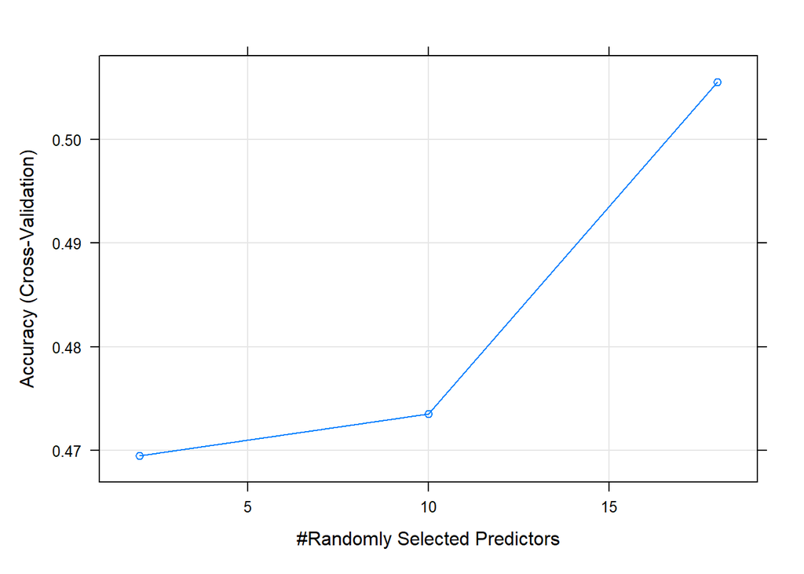

```r
plot(sales_rf)
```

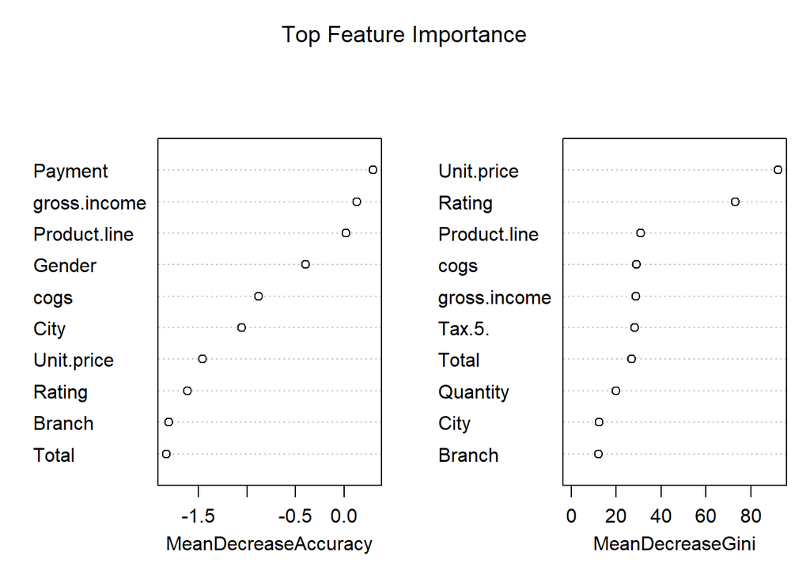

```r
# RandomForest Model
sales_randomF <- randomForest(Customer.type ~ .,
                data = sales_train_imp, method="rf",
                  trControl=control_rf, ntree=80, mtry = 10,
                importance = TRUE,
                proximity = TRUE
                  )
varImpPlot(sales_randomF, sort=T, n.var = 10, main = 'Top Feature Importance')
```

**Tree Model**

```r
library(caret)
library(rlang)
library(rpart)
```

```r
library(rpart.plot)

sales_train_imp$Customer.type <- factor(sales_train$Customer.type, levels = c("Member", "Normal"))

sales_test_imp$Customer.type <- factor(sales_test$Customer.type, levels = c("Member", "Normal"))


# build model with Classification Tree
modFit.rpart <- train(Customer.type ~ .,
                data = sales_train_imp,
                      method = "rpart" )

pred.rpart <- predict(modFit.rpart, sales_test_imp)

confusionMatrix(pred.rpart, sales_test_imp$Customer.type)
```

```
## Confusion Matrix and Statistics
##
##           Reference
## Prediction Member Normal
##     Member     71     85
##     Normal     39     55
##
##                Accuracy : 0.504
##                  95% CI : (0.4403, 0.5676)
##     No Information Rate : 0.56
##     P-Value [Acc > NIR] : 0.9673
##
##                   Kappa : 0.0367
##
##  Mcnemar's Test P-Value : 5.32e-05
##
##             Sensitivity : 0.6455
##             Specificity : 0.3929
##          Pos Pred Value : 0.4551
##          Neg Pred Value : 0.5851
##              Prevalence : 0.4400
##          Detection Rate : 0.2840
##    Detection Prevalence : 0.6240
##       Balanced Accuracy : 0.5192
##
##        'Positive' Class : Member
##
```

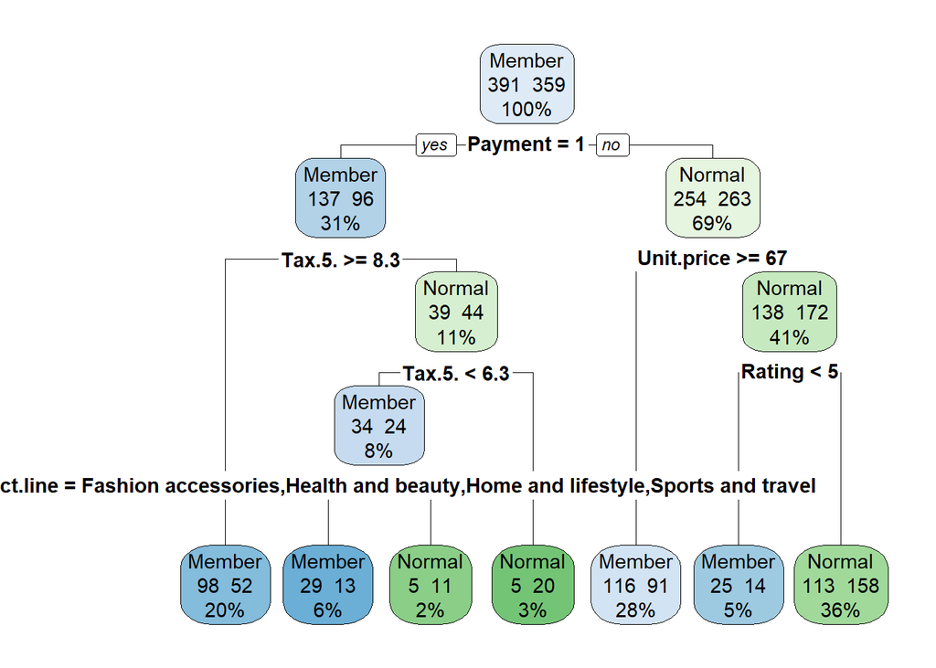

```r
sales_tree = rpart(Customer.type ~ .,
                data = sales_train_imp )

rpart.plot(sales_tree, type = 2, extra = 101, leaf.round = 3, fallen.leaves = TRUE,
    varlen = 0, tweak = 1.1
    )
```

**Market Basket Analysis**

```r
library(arules)
## Find association rules between product lines and customers' Ratings
#Convert to transaction class:
trans_product <- as(split(salesdf[,"Product.line"], salesdf[,"Rating"], salesdf[,"Quantity"], salesdf[,"Customer.type"], salesdf[,"Payment"]), "transactions")
summary(trans_product)
```

```
## transactions as itemMatrix in sparse format with
##  61 rows (elements/itemsets/transactions) and
##  6 columns (items) and a density of 0.931694
##
## most frequent items:
##    Fashion accessories Electronic accessories      Sports and travel
##                     59                     58                     57
##     Food and beverages     Home and lifestyle                (Other)
##                     56                     56                     55
##
## element (itemset/transaction) length distribution:
## sizes
##  3  4  5  6
##  1  2 18 40
##
##    Min. 1st Qu.  Median    Mean 3rd Qu.    Max.
##    3.00    5.00    6.00    5.59    6.00    6.00
##
## includes extended item information - examples:
##                   labels
## 1 Electronic accessories
## 2    Fashion accessories
## 3     Food and beverages
##
## includes extended transaction information - examples:
##   transactionID
## 1             4
## 2           4.1
## 3           4.2
```

```r
inspect(trans_product[1:5])
```

```
##     items                     transactionID
## [1] {Electronic accessories,
##      Fashion accessories,
##      Food and beverages,
##      Health and beauty,
##      Sports and travel}                 4
## [2] {Electronic accessories,
##      Fashion accessories,
##      Food and beverages,
##      Health and beauty,
##      Home and lifestyle,
##      Sports and travel}                 4.1
## [3] {Electronic accessories,
##      Fashion accessories,
##      Food and beverages,
##      Health and beauty,
##      Home and lifestyle,
##      Sports and travel}                 4.2
## [4] {Electronic accessories,
##      Fashion accessories,
##      Food and beverages,
##      Health and beauty,
##      Home and lifestyle,
##      Sports and travel}                 4.3
## [5] {Electronic accessories,
##      Fashion accessories,
##      Food and beverages,
##      Health and beauty,
##      Home and lifestyle,
##      Sports and travel}                 4.4
```

```r
itemFrequency(trans_product[, 1:3])
```

```
## Electronic accessories    Fashion accessories     Food and beverages
##              0.9508197              0.9672131              0.9180328
```

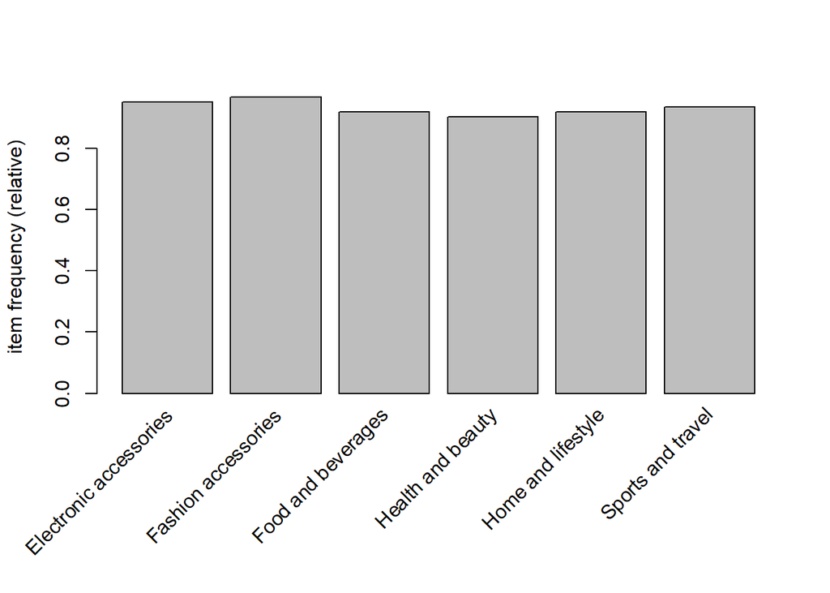

```r
#Visualizing item support – item frequency plots
itemFrequencyPlot(trans_product, support = 0.1)
```

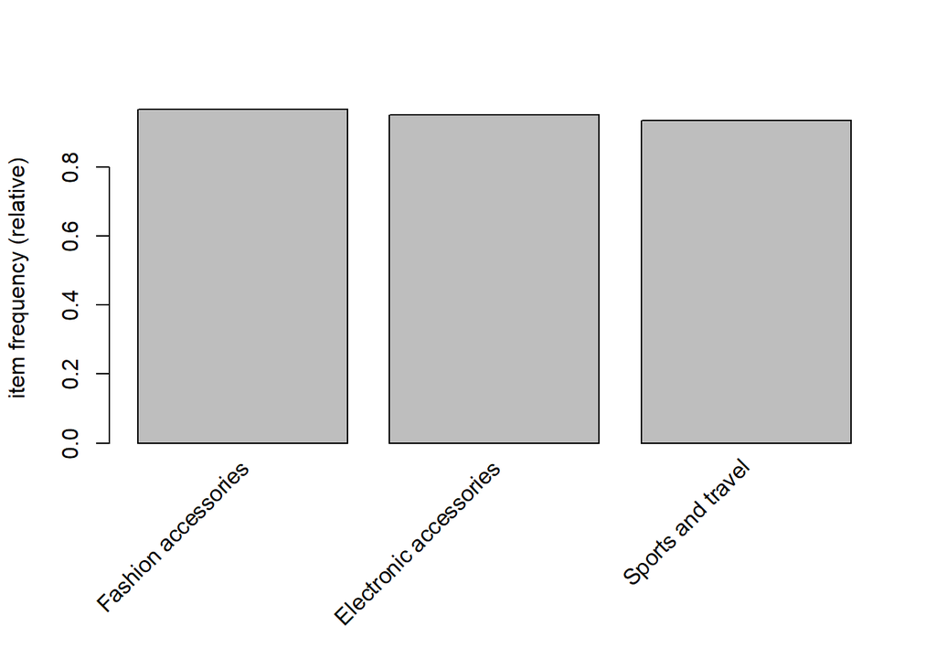

```r
itemFrequencyPlot(trans_product, topN = 3)
```

```r
## Training a model on the data
# if an item is purchased twice a day (about 60 times in a month of data) then 60/1000 = 0.06
product_rules <- apriori(trans_product, parameter = list(support = 0.06, confidence = 0.25, minlen = 2))
```

```
## Apriori
##
## Parameter specification:
##  confidence minval smax arem  aval originalSupport maxtime support minlen
##        0.25    0.1    1 none FALSE            TRUE       5    0.06      2
##  maxlen target  ext
##      10  rules TRUE
##
## Algorithmic control:
##  filter tree heap memopt load sort verbose
##     0.1 TRUE TRUE  FALSE TRUE    2    TRUE
##
## Absolute minimum support count: 3
##
## set item appearances ...[0 item(s)] done [0.00s].
## set transactions ...[6 item(s), 61 transaction(s)] done [0.00s].
## sorting and recoding items ... [6 item(s)] done [0.00s].
## creating transaction tree ... done [0.00s].
## checking subsets of size 1 2 3 4 5 6 done [0.00s].
## writing ... [186 rule(s)] done [0.00s].
## creating S4 object  ... done [0.00s].
```

```r
inspect(product_rules[1:3])
```

```
##     lhs                     rhs                  support   confidence coverage
## [1] {Health and beauty}  => {Home and lifestyle} 0.8196721 0.9090909  0.9016393
## [2] {Home and lifestyle} => {Health and beauty}  0.8196721 0.8928571  0.9180328
## [3] {Health and beauty}  => {Food and beverages} 0.8196721 0.9090909  0.9016393
##     lift      count
## [1] 0.9902597 50
## [2] 0.9902597 50
## [3] 0.9902597 50
```

```r
## Evaluating model performance
 summary(product_rules)
```

```
## set of 186 rules
##
## rule length distribution (lhs + rhs):sizes
##  2  3  4  5  6
## 30 60 60 30  6
##
##    Min. 1st Qu.  Median    Mean 3rd Qu.    Max.
##   2.000   3.000   4.000   3.581   4.000   6.000
##
## summary of quality measures:
##     support         confidence        coverage           lift
##  Min.   :0.6557   Min.   :0.8696   Min.   :0.6721   Min.   :0.9644
##  1st Qu.:0.7254   1st Qu.:0.9188   1st Qu.:0.7869   1st Qu.:0.9881
##  Median :0.7705   Median :0.9362   Median :0.8443   Median :0.9974
##  Mean   :0.7805   Mean   :0.9330   Mean   :0.8368   Mean   :1.0014
##  3rd Qu.:0.8197   3rd Qu.:0.9455   3rd Qu.:0.8852   3rd Qu.:1.0132
##  Max.   :0.9180   Max.   :0.9821   Max.   :0.9672   Max.   :1.0474
##      count
##  Min.   :40.00
##  1st Qu.:44.25
##  Median :47.00
##  Mean   :47.61
##  3rd Qu.:50.00
##  Max.   :56.00
##
## mining info:
##           data ntransactions support confidence
##  trans_product            61    0.06       0.25
##                                                                                            call
##  apriori(data = trans_product, parameter = list(support = 0.06, confidence = 0.25, minlen = 2))
```

```r
## Improving model performance
inspect(sort(product_rules, by = "lift")[1:5])
```

```
##     lhs                          rhs                    support confidence  coverage     lift count
## [1] {Home and lifestyle,
##      Sports and travel}       => {Food and beverages} 0.8196721  0.9615385 0.8524590 1.047390    50
## [2] {Fashion accessories,
##      Home and lifestyle,
##      Sports and travel}       => {Food and beverages} 0.8032787  0.9607843 0.8360656 1.046569    49
## [3] {Electronic accessories,
##      Home and lifestyle,
##      Sports and travel}       => {Food and beverages} 0.7704918  0.9591837 0.8032787 1.044825    47
## [4] {Electronic accessories,
##      Fashion accessories,
##      Home and lifestyle,
##      Sports and travel}       => {Food and beverages} 0.7540984  0.9583333 0.7868852 1.043899    46
## [5] {Health and beauty,
##      Home and lifestyle,
##      Sports and travel}       => {Food and beverages} 0.7213115  0.9565217 0.7540984 1.041925    44
```

## Part II: Credit Card Fraud

URL: https://www.kaggle.com/datasets/dhanushnarayananr/credit-card-fraud

Feature Explanation:

distancefromhome - the distance from home where the transaction happened.

distancefromlast_transaction - the distance from last transaction happened.

ratiotomedianpurchaseprice - Ratio of purchased price transaction to median purchase price.

repeat_retailer - Is the transaction happened from same retailer. (1-Yes / 0-No)

used_chip - Is the transaction through chip (credit card). (1-Yes / 0-No)

usedpinnumber - Is the transaction happened by using PIN number. (1-Yes / 0-No)

online_order - Is the transaction an online order. (1-Yes / 0-No)

fraud - Is the transaction fraudulent. (1-Yes / 0-No)

```r
credit_dt <- read.csv(file = "C:/Users/Anhuynh/Desktop/ITU/Classes/Principles of Business Analytics/Assignments/Dataset/card_transdata.csv")
```

```r
##Find missing values
colSums(is.na(credit_dt))
```

```
##             distance_from_home distance_from_last_transaction
##                              0                              0
## ratio_to_median_purchase_price                repeat_retailer
##                              0                              0
##                      used_chip                used_pin_number
##                              0                              0
##                   online_order                          fraud
##                              0                              0
```

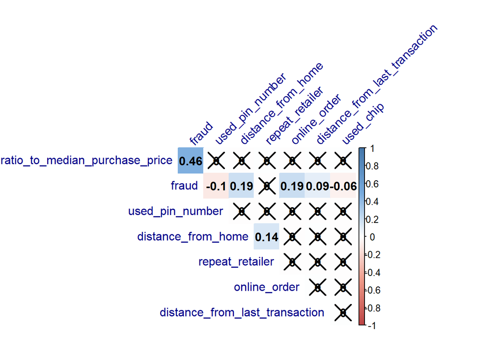

```r
library(corrplot)
library(Hmisc)

## Mark the insignificant coefficients according to the specified p-value significance level
cor_9 <- rcorr(as.matrix(credit_dt))
credit_cor <- cor_9$r
p_mat <- cor_9$P

col <- colorRampPalette(c("#BB4444", "#EE9988", "#FFFFFF", "#77AADD", "#4477AA"))

corrplot(credit_cor, method = "color", col = col(200),
         type = "upper", order = "hclust",
         addCoef.col = "black", # Add coefficient of correlation
         tl.col = "darkblue", tl.srt = 45, #Text label color and rotation
         # Combine with significance level
         p.mat = p_mat, sig.level = 0.01,
         # hide correlation coefficient on the principal diagonal
         diag = FALSE
         )
```

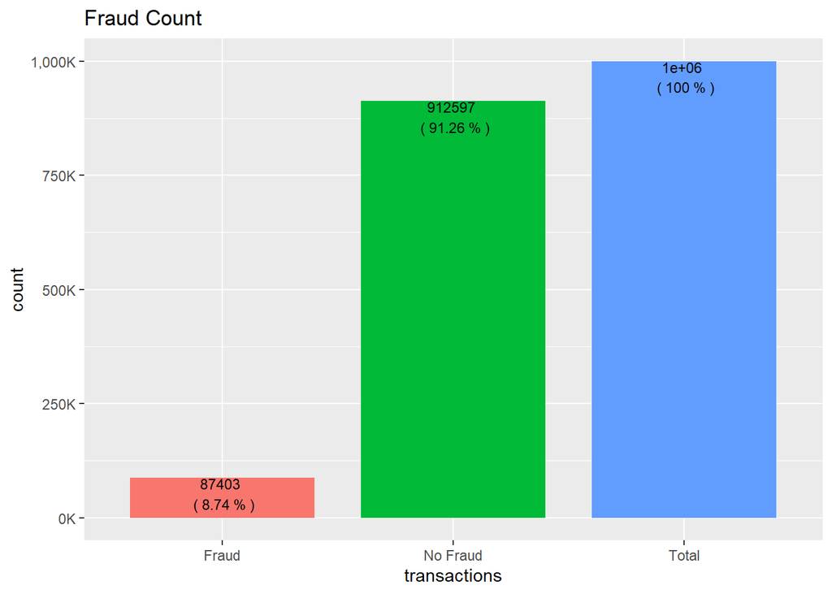

```r
library(ggplot2)
library(scales)
library(stringr)
##Exploratory Data Analysis
# fraud
count_fraud <- table(credit_dt$fraud)

df_fraud <- data.frame(transactions = c("No Fraud", "Fraud", "Total" ),
                      count = c(912597, 87403, 1000000))

ggplot(data=df_fraud, aes(x = transactions, y = count, fill = transactions)) +
geom_bar(stat="identity", width=0.8) +
geom_text(aes(y=df_fraud$count, label= paste(df_fraud$count,"\n", "(", round(df_fraud$count/10^6*100,2), "%" , ")")), vjust=1, color="black", size=3) +
labs(title="Fraud Count") +
theme(legend.position="none") +
scale_y_continuous(labels  =
                       label_number(scale = 1e-3, prefix = "", suffix = "K", big.mark = ',',  accuracy = 1))
```

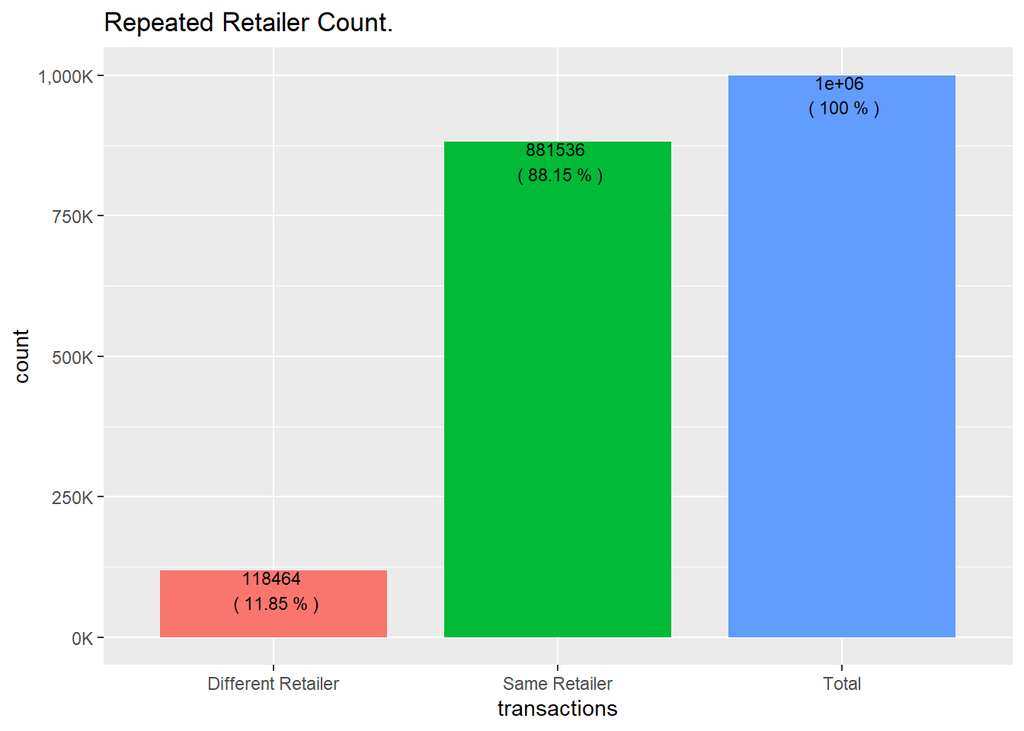

```r
# repeat_retailer
count_retailer <- table(credit_dt$repeat_retailer)

df_retailer <- data.frame(transactions = c("Different Retailer", "Same Retailer", "Total" ),
                      count = c(118464, 881536, 1000000))

ggplot(data=df_retailer, aes(x = transactions, y = count, fill = transactions)) +
geom_bar(stat="identity", width=0.8) +
geom_text(aes(y=df_retailer$count, label= paste(df_retailer$count,"\n", "(", round(df_retailer$count/10^6*100,2), "%" , ")")), vjust=1, color="black", size=3) +
labs(title="Repeated Retailer Count.") +
theme(legend.position="none") +
scale_y_continuous(labels  =
                       label_number(scale = 1e-3, prefix = "", suffix = "K", big.mark = ',',  accuracy = 1))
```

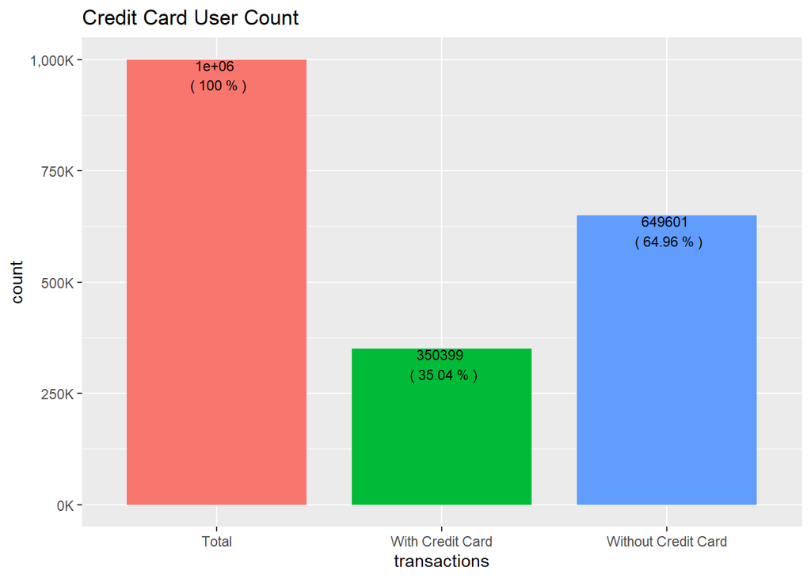

```r
# used_chip (credit card)
count_chip <- table(credit_dt$used_chip)

df_chip <- data.frame(transactions = c("Without Credit Card", "With Credit Card", "Total" ),
                      count = c(649601, 350399, 1000000))

ggplot(data=df_chip, aes(x = transactions, y = count, fill = transactions)) +
geom_bar(stat="identity", width=0.8) +
geom_text(aes(y=df_chip$count, label= paste(df_chip$count,"\n", "(", round(df_chip$count/10^6*100,2), "%" , ")")), vjust=1, color="black", size=3) +
labs(title="Credit Card User Count") +
theme(legend.position="none") +
scale_y_continuous(labels  =
                       label_number(scale = 1e-3, prefix = "", suffix = "K", big.mark = ',',  accuracy = 1))
```

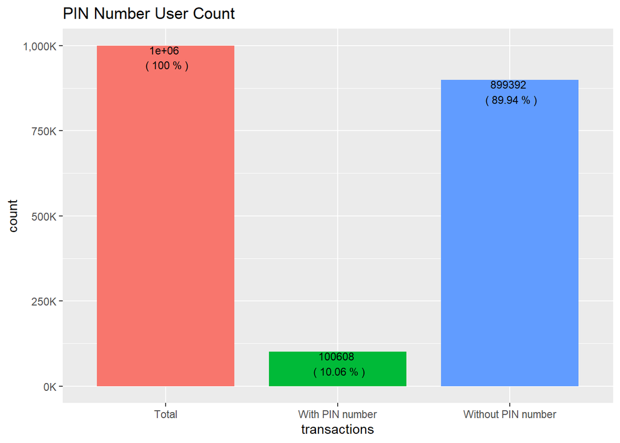

```r
# used_pin_number (PIN number)
count_pin <- table(credit_dt$used_pin_number)

df_pin <- data.frame(transactions = c("Without PIN number", "With PIN number", "Total" ),
                      count = c(899392, 100608, 1000000))

ggplot(data=df_pin, aes(x = transactions, y = count, fill = transactions)) +
geom_bar(stat="identity", width=0.8) +
geom_text(aes(y=df_pin$count, label= paste(df_pin$count,"\n", "(", round(df_pin$count/10^6*100,2), "%" , ")")), vjust=1, color="black", size=3) +
labs(title="PIN Number User Count") +
theme(legend.position="none") +
scale_y_continuous(labels  =
                       label_number(scale = 1e-3, prefix = "", suffix = "K", big.mark = ',',  accuracy = 1))
```

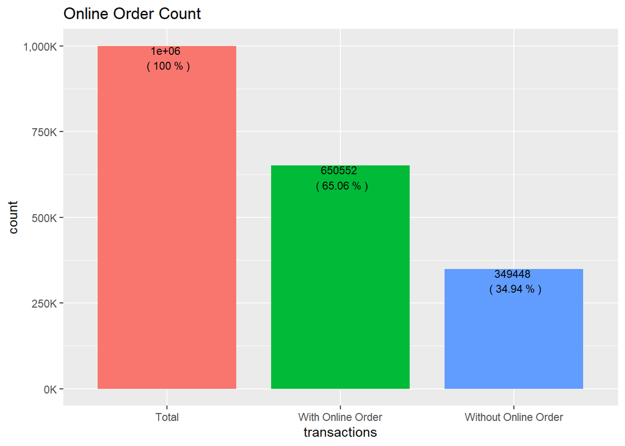

```r
# online_order
count_order <- table(credit_dt$online_order)

df_order <- data.frame(transactions = c("Without Online Order", "With Online Order", "Total" ),
                      count = c(349448, 650552, 1000000))

ggplot(data=df_order, aes(x = transactions, y = count, fill = transactions)) +
geom_bar(stat="identity", width=0.8) +
geom_text(aes(y=df_order$count, label= paste(df_order$count,"\n", "(", round(df_order$count/10^6*100,2), "%" , ")")), vjust=1, color="black", size=3) +
labs(title="Online Order Count") +
theme(legend.position="none") +
scale_y_continuous(labels  =
                       label_number(scale = 1e-3, prefix = "", suffix = "K", big.mark = ',',  accuracy = 1))
```

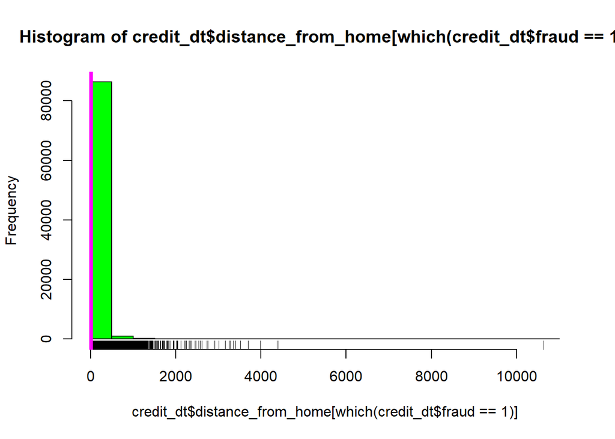

```r
## Distribution of the variables counts, or how many transactions fall into each bucket of measurements.
# distance_from_home
## with Fraud
hist(credit_dt$distance_from_home[which(credit_dt$fraud == 1)], col = "green")
rug(credit_dt$distance_from_home[which(credit_dt$fraud == 1)])
abline(v = median(credit_dt$distance_from_home[which(credit_dt$fraud == 1)]), col = "magenta", lwd = 4)
```

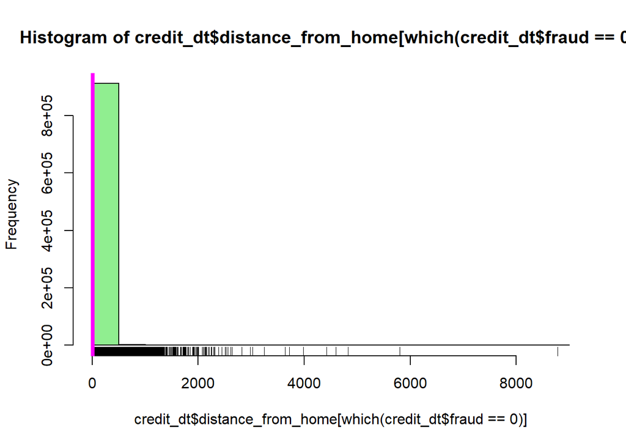

```r
## without Fraud
hist(credit_dt$distance_from_home[which(credit_dt$fraud == 0)], col = "light green")
rug(credit_dt$distance_from_home[which(credit_dt$fraud == 0)])
abline(v = median(credit_dt$distance_from_home[which(credit_dt$fraud == 0)]), col = "magenta", lwd = 4)
```

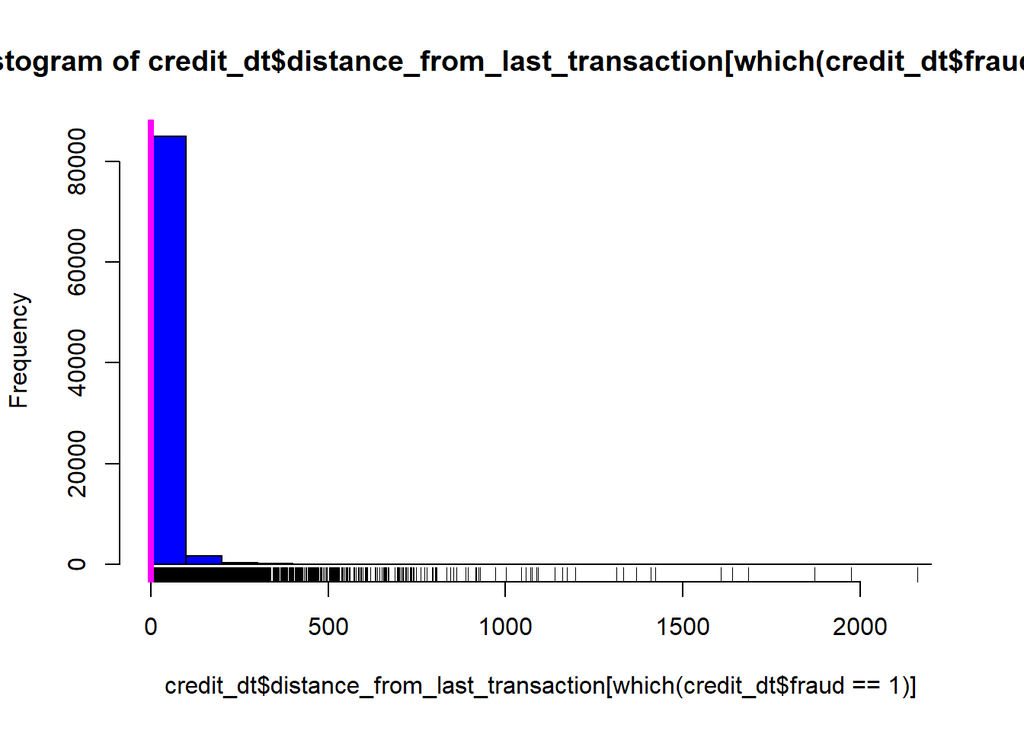

```r
# distance_from_last_transaction
hist(credit_dt$distance_from_last_transaction[which(credit_dt$fraud == 1)], col = "blue")
rug(credit_dt$distance_from_last_transaction[which(credit_dt$fraud == 1)])
abline(v = median(credit_dt$distance_from_last_transaction[which(credit_dt$fraud == 1)]), col = "magenta", lwd = 4)
```

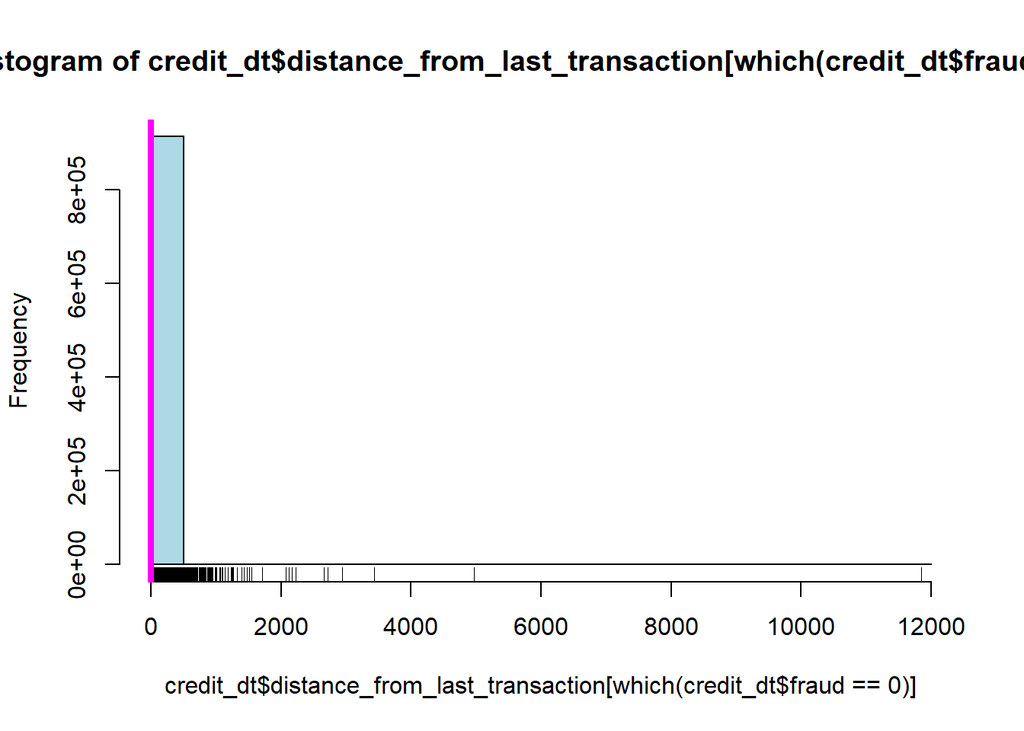

```r
hist(credit_dt$distance_from_last_transaction[which(credit_dt$fraud == 0)], col = "light blue")
rug(credit_dt$distance_from_last_transaction[which(credit_dt$fraud == 0)])
abline(v = median(credit_dt$distance_from_last_transaction[which(credit_dt$fraud == 0)]), col = "magenta", lwd = 4)
```

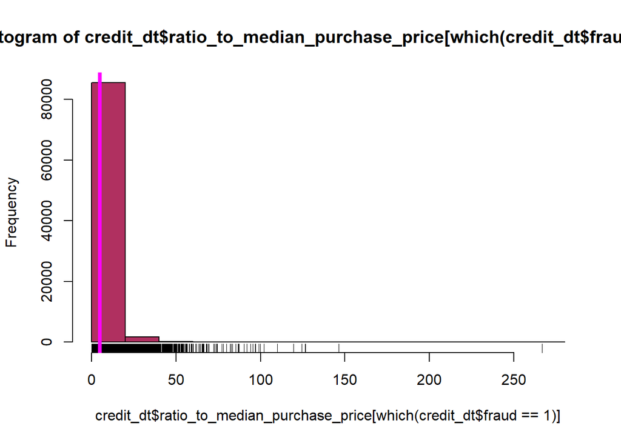

```r
# ratio_to_median_purchase_price
hist(credit_dt$ratio_to_median_purchase_price[which(credit_dt$fraud == 1)], col = "maroon")
rug(credit_dt$ratio_to_median_purchase_price[which(credit_dt$fraud == 1)])
abline(v = median(credit_dt$ratio_to_median_purchase_price[which(credit_dt$fraud == 1)]), col = "magenta", lwd = 4)
```

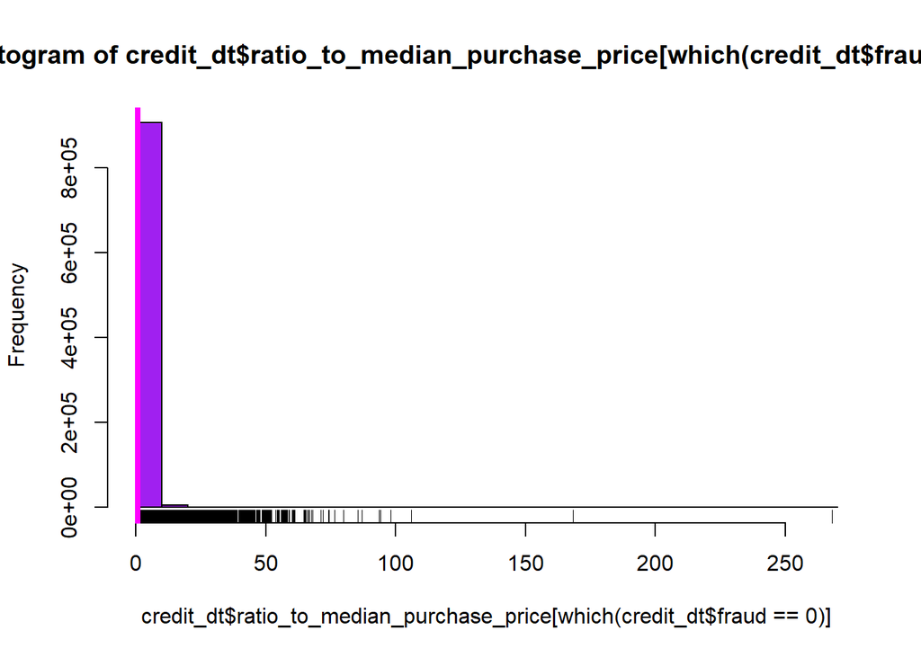

```r
hist(credit_dt$ratio_to_median_purchase_price[which(credit_dt$fraud == 0)], col = "purple")
rug(credit_dt$ratio_to_median_purchase_price[which(credit_dt$fraud == 0)])
abline(v = median(credit_dt$ratio_to_median_purchase_price[which(credit_dt$fraud == 0)]), col = "magenta", lwd = 4)
```

**Data Modeling:**

```r
library(tidymodels)
## Split the data into training and test sets
set.seed(2023)
credit_split <- initial_split(credit_dt,  prop = 3/4)
credit_train <- training(credit_split) # training set
credit_test <- testing(credit_split) # test set
```

**Logistic Regression Model**

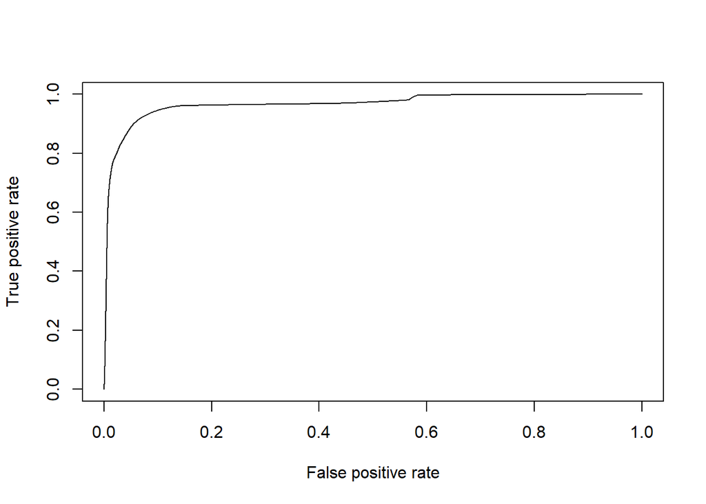

```r
library(caret)
library(pROC)
library(ROCR)

credit_train$fraud <- factor(credit_train$fraud)
credit_test$fraud <- factor(credit_test$fraud)

# Receiver operating characteristic (ROC) curve is commonly used to examine the tradeoff between the detection of true positives while avoiding the false positives.
credit_gml <- glm(fraud ~ distance_from_home + distance_from_last_transaction + ratio_to_median_purchase_price + repeat_retailer + used_chip + used_pin_number + online_order, family = "binomial", data = credit_train)
credit.probs <- predict(credit_gml, credit_test, type="response")

pr <- prediction(credit.probs, credit_test$fraud)

# plotting ROC curve
prf <- performance(pr, measure = "tpr", x.measure = "fpr")
plot(prf)
```

```r
auc <- performance(pr, measure = "auc")
auc <- auc@y.values[[1]]
auc
```

```
## [1] 0.9668457
```

```r
# Calculate a test misclassification rate
table(credit_test$fraud) / nrow(credit_test)
```

```
##
##        0        1
## 0.912112 0.087888
```

**What does AUC mean?** The Area Under the Curve (AUC) is the measure of the ability of a classifier to distinguish between classes and is used as a summary of the ROC curve. The higher the AUC, the better the performance of the model at distinguishing between the positive and negative classes.

**Calculate cost-saving per Transaction.** If we assume that fraud loss/cost is approximately $4 per transaction, which is the cost to handle a fraud transaction, which is predicted as “non-Fraud” (False Negative). Otherwise, the cost will be four time less expensive to handle an existing fraud or $1 per transaction, which is predicted as “Fraud” (True Positive)

FN (predict that a transaction wouldn’t be fraud, but it actually would, then loss will be): $4 TP (predict that a transaction would be fraud , when it actually would): $1 FP (predict that a transaction would be fraud , when it actually wouldn’t): $1 TN (predict that a transaction wouldn’t be fraud, when it actually wouldn’t): $0 Cost = FN($4) + TP($1) + FP($1) + TN($0)

**Apply this cost evaluation to our model.** We start by fitting the model, and making predictions in the form of probabilities.

```r
## let’s create a threshold vector and a cost vector.
# threshold vector
thresh <- seq(0.1,1.0, length = 10)

#cost vector
cost = rep(0,length(thresh))

dim(credit_test) ## 250,000
```

```
## [1] 250000      8
```

```r
# cost as a function of threshold
for (i in 1:length(thresh)){

  glm.pred = rep("No", length(credit.probs))
  glm.pred <- ifelse(credit.probs > thresh[[i]], 1, 0)
  glm.pred <- as.factor(glm.pred)
  credit_test$fraud <- as.factor(credit_test$fraud)

  x <- confusionMatrix(glm.pred, credit_test$fraud)
  TN <- x$table[1]/250000
  FP <- x$table[2]/250000
  FN <- x$table[3]/250000
  TP <- x$table[4]/250000

  cost[i] = FN*4 + TP*1 + FP*1 + TN*0
}
##Confusion Matrix
x
```

```
## Confusion Matrix and Statistics
##
##           Reference
## Prediction      0      1
##          0 228028  21972
##          1      0      0
##
##                Accuracy : 0.9121
##                  95% CI : (0.911, 0.9132)
##     No Information Rate : 0.9121
##     P-Value [Acc > NIR] : 0.5018
##
##                   Kappa : 0
##
##  Mcnemar's Test P-Value : <2e-16
##
##             Sensitivity : 1.0000
##             Specificity : 0.0000
##          Pos Pred Value : 0.9121
##          Neg Pred Value :    NaN
##              Prevalence : 0.9121
##          Detection Rate : 0.9121
##    Detection Prevalence : 1.0000
##       Balanced Accuracy : 0.5000
##
##        'Positive' Class : 0
##
```

**Let’s assume that the company is using “simple model” which just defaults to a threshold of 0.5. We need fit that model, make predictions, and calculate the cost.**

```r
# simple model: assume threshold is 0.5
glm.pred = rep("No", length(credit.probs))
glm.pred <- ifelse(credit.probs > 0.5, 1, 0)
glm.pred <- as.factor(glm.pred)
credit_test$fraud <- as.factor(credit_test$fraud)

x <- confusionMatrix(glm.pred, credit_test$fraud)
TN <- x$table[1]/250000
FP <- x$table[2]/250000
FN <- x$table[3]/250000
TP <- x$table[4]/250000

cost_simple = FN*4 + TP*1 + FP*1 + TN*0
```

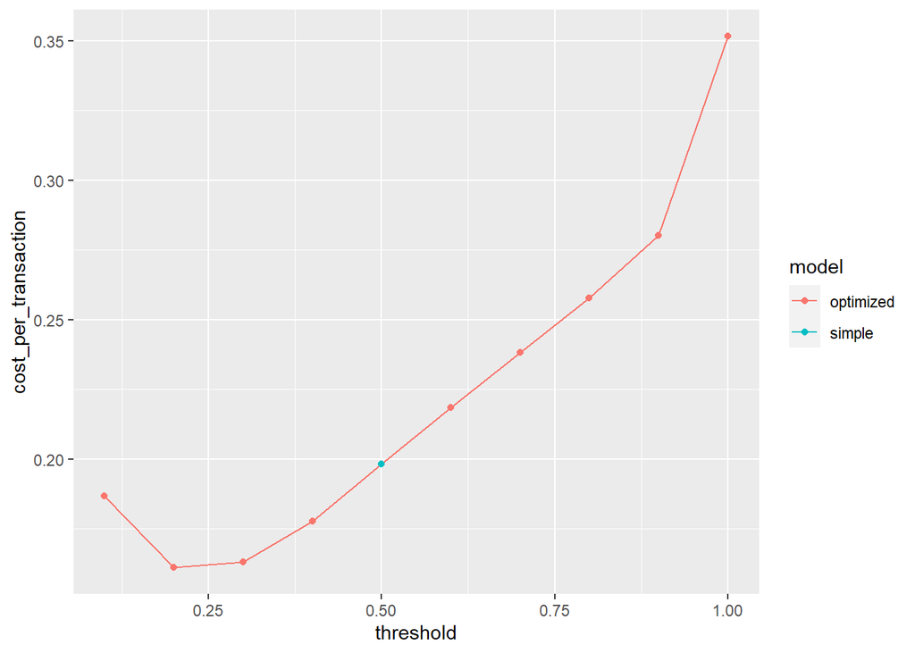

```r
# putting results in a dataframe for plotting
dat <- data.frame(
  model = c(rep("optimized",10),"simple"),
  cost_per_transaction = c(cost, cost_simple),
  threshold = c(thresh, 0.5)
)

# plotting
ggplot(dat, aes(x = threshold, y = cost_per_transaction, group = model, colour = model)) +
  geom_line() +
  geom_point()
```

**As if we have 1,000,000 transactions to be switched from existing model to new model, the cost-saving will be:**

```r
# cost savings of optimized model (threshold = 0.2) compared to baseline model (threshold = 0.5)
savings_per_transaction = cost_simple - min(cost)

total_savings = 1000000*savings_per_transaction

total_savings
```

```
## [1] 37052
```

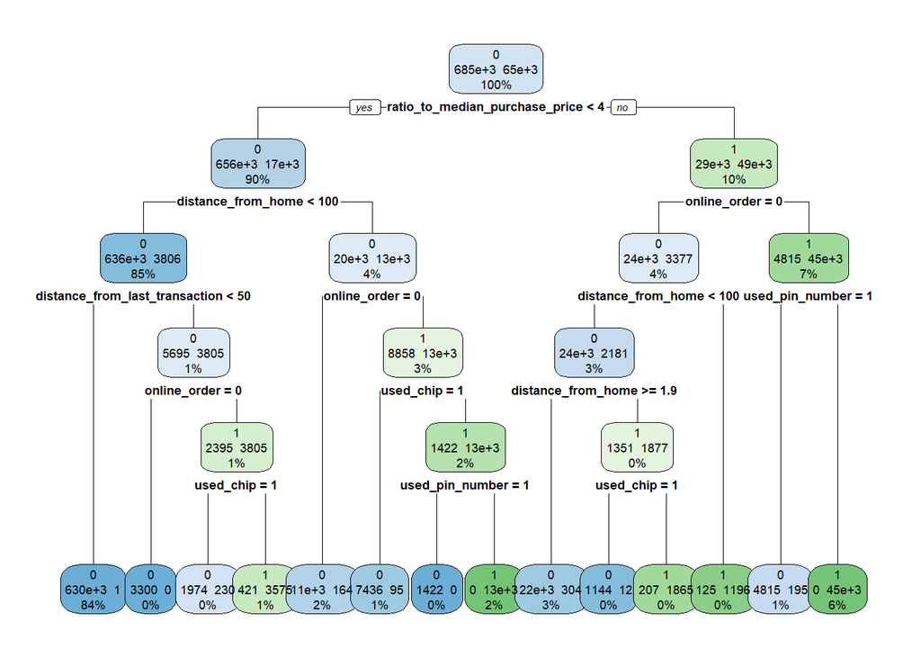

```r
library(rlang)
library(rpart.plot)

credit_tree = rpart(fraud ~ distance_from_home + distance_from_last_transaction + ratio_to_median_purchase_price + repeat_retailer + used_chip + used_pin_number + online_order,
              data = credit_train )

rpart.plot(credit_tree, type = 2, extra = 101, leaf.round = 3, fallen.leaves = TRUE,
    varlen = 0, tweak = 1.2)
```

```r
credit_tree_tst_pred = predict(credit_tree, credit_test, type = "class")
table(predicted = credit_tree_tst_pred, actual = credit_test$fraud)
```

```
##          actual
## predicted      0      1
##         0 227774    358
##         1    254  21614
```

```r
# function to predict accuracy of Classification tree model
calc_acc = function(actual, predicted) {
  mean(actual == predicted)
}

# Accuracy
(tree_tst_acc = calc_acc(predicted = credit_tree_tst_pred, actual = credit_test$fraud))
```

```
## [1] 0.997552
```

```r
# Out-of-sample-error in test set
OOSE <- 1 - as.numeric(confusionMatrix(credit_test$fraud, credit_tree_tst_pred)$overall[1])
OOSE
```

```
## [1] 0.002448
```